# Project: Exploring FBI gun background check data from 1998-2017, more specifically 2011-2015.

- Introduction
- Data Wrangling
- Exploratory Data Analysis
- Conclusions

## Introduction

> For this project I wanted to investigate the trends in gun permits that were issued from 1998-2017. The provided materials were FBI background check data from 1998-2017 as well as US census information from 2010-2016. Below are the questions I'd like to answer.

> **From the gun data that was provided, what was the overall trend in gun permits issued from 1998-2017?**

> **From the answer above (the overall trend of gun permits issued) in what year and states were the highest amount of gun permits issued?**

> **What states from 2011-2015 had the highest amount of gun permits issued? The census data has provided certain variables from 2011-2015, I'd like to see in the states that had the highest amount of gun permits issued from 2011-2015 and find the following:**

> The percentage of people with a bachelors degree or higher

> The percentage of people with a disability

> The percentage of people who went without health insurance

> The percentage of persons in poverty

> The percentage of people who are foreign born

> The percentage of people (5 years or age and older) who speak more than one language at home</b>

# gun_data_xlsx

> Each column represents the type of transaction submitted to the National Instant Criminal Background Check System (NICS). In addition, each type of transaction is broken down by the type of firearm—handgun, long gun, and other. The types of firearms are defined by the Bureau of Alcohol, Tobacco, Firearms and Explosives as follows:
> - **month**: The month in which the background check took place.
> - **state**: The state in which the background check took place.
> - **permit**: The number of permits that were issued to individuals upon successful completion of a background check.
> - **permit_recheck**: How many of the above permits that were issued were rechecked.
> - **handgun**: (a) any firearm which has a short stock and is designed to be held and fired by the use of a single hand; and (b) any combination of parts from which a firearm described in paragraph (a) can be assembled.
> - **long_gun**: a weapon designed or redesigned, made or remade, and intended to be fired from the shoulder, and designed or redesigned and made or remade to use the energy of the explosive in (a) a fixed metallic cartridge to fire a single projectile through a rifled bore for each single pull of the trigger; or (b) a fixed shotgun shell to fire through a smooth bore either a number of ball shot or a single projectile for each single pull of the trigger.
> - **other**: refers to frames, receivers, and other firearms that are neither handguns nor long guns (rifles or shotguns), such as firearms having a pistol grip that expel a shotgun shell, or National Firearms Act firearms, including silencers.
> - **multiple**: denotes a background check where more than one type of firearm is associated to a single background check.
> - **admin**: denotes the administrative checks that are for other authorized uses of the NICS.
> - **What does 'prepawn' mean?** background checks requested by an officially-licensed FFL on prospective firearm transferees seeking to pledge or pawn a firearm as security for the payment or repayment of money, prior to actually pledging or pawning the firearm. This will be associated with the **prepawn_handgun**, **prepawn_long_gun**, and **prepawn_other** columns.
> - **What does 'redemption' mean?** background checks requested by an officially-licensed FFL on prospective firearm transferees attempting to regain possession of a firearm after pledging or pawning a firearm as security at a pawn shop. This will be associated with the **redemption_handgun**, **redemption_long_gun**, and **redemption_other** columns.
> - **What does 'returned' mean?** background checks requested by criminal justice/law enforcement agencies prior to returning a firearm in its possession to the respective transferee, to ensure the individual is not prohibited. These will be associated with the **returned_handgun****returned_long_gun** and **returned_other** columns.
> - **What does 'rentals' means?** background checks requested by an officially-licensed FFL on prospective firearm transferees attempting to possess a firearm when the firearm is loaned or rented for use off the premises of the business. These will be associated with the **rentals_handgun** and **rentals_long_gun** columns.
> - **What does 'private sale' mean?** background checks requested by an officially-licensed FFL on prospective firearm transferees attempting to possess a firearm from a private party seller who is not an officially-licensed FFL. These will be associated with the **private_sale_handgun**, **private_sale_long_gun** and **private_sale_other** columns.
> - **What does 'return to seller' mean?** background checks requested by an officially-licensed FFL on prospective firearm transferees attempting to possess a firearm from a private party seller who is not an officially-licensed FFL. This will be associated with the **return_to_seller_handgun**, **return_to_seller_long_gun**, and **return_to_seller_other** columns.
> - **totals**: The total calculation of each row from every column.

> The above information was taken directly from https://www.fbi.gov/file-repository/nics_firearm_checks_-_month_year_by_state_type.pdf/view, which is an originial pdf file of the gun_data_csv. Supplemental information was taken from https://www.fbi.gov/how-we-can-help-you/need-an-fbi-service-or-more-information/nics. Both of these sources were provided via link from the original project on Github, https://github.com/BuzzFeedNews/nics-firearm-background-checks/blob/master/README.md.

# US_Census_Data_csv

> This data set is supplemental to the above gun_data_csv. It is census data that has variable data points. Some for the year 2010, 2012, 2016 as well as some cumilative data for 2010-2015 in certain rows. The columns are "Facts", "Fact Note", as well as individual columns for all 50 states. Under the "Facts" column are the variable for which the state data is provided. The "Facts" are seperated into individual rows. They are listed below and self explanatory.
> - **Population estimates, July 1, 2016, (V2016)**
> - **Population estimates base, April 1, 2010, (V2016)**
> - **Population, percent change - April 1, 2010 (estimates base) to July 1, 2016, (V2016)**
> - **Population, Census, April 1, 2010**
> - **Persons under 5 years, percent, July 1, 2016, (V2016)**
> - **Persons under 5 years, percent, April 1, 2010**
> - **Persons under 18 years, percent, July 1, 2016, (V2016)**
> - **Persons under 18 years, percent, April 1, 2010**
> - **Persons 65 years and over, percent, July 1, 2016, (V2016)**
> - **Persons 65 years and over, percent, April 1, 2010**
> - **Female persons, percent, July 1, 2016, (V2016)**
> - **Female persons, percent, April 1, 2010**
> - **White alone, percent, July 1, 2016, (V2016)**
> - **Black or African American alone, percent, July 1, 2016, (V2016)**
> - **American Indian and Alaska Native alone, percent, July 1, 2016, (V2016)**
> - **Asian alone, percent, July 1, 2016, (V2016)**
> - **Native Hawaiian and Other Pacific Islander alone, percent, July 1, 2016, (V2016)**
> - **Two or More Races, percent, July 1, 2016, (V2016)**
> - **Hispanic or Latino, percent, July 1, 2016, (V2016)**
> - **White alone, not Hispanic or Latino, percent, July 1, 2016, (V2016)**
> - **Veterans, 2011-2015**
> - **Foreign born persons, percent, 2011-2015**
> - **Housing units, July 1, 2016, (V2016)**
> - **Housing units, April 1, 2010**
> - **Owner-occupied housing unit rate, 2011-2015**
> - **Median value of owner-occupied housing units, 2011-2015**
> - **Median selected monthly owner costs -with a mortgage, 2011-2015**
> - **Median selected monthly owner costs -without a mortgage, 2011-2015**
> - **Median gross rent, 2011-2015**
> - **Building permits, 2016**
> - **Households, 2011-2015**
> - **Persons per household, 2011-2015**
> - **Living in same house 1 year ago, percent of persons age 1 year+, 2011-2015**
> - **Language other than English spoken at home, percent of persons age 5 years+, 2011-2015**
> - **High school graduate or higher, percent of persons age 25 years+, 2011-2015**
> - **Bachelor's degree or higher, percent of persons age 25 years+, 2011-2015**
> - **With a disability, under age 65 years, percent, 2011-2015**
> - **Persons without health insurance, under age 65 years, percent**
> - **In civilian labor force, total, percent of population age 16 years+, 2011-2015**
> - **In civilian labor force, female, percent of population age 16 years+, 2011-2015**
> - **Total accommodation and food services sales, 2012 (\\$1,000)**
> - **Total health care and social assistance receipts and revenue, 2012 (\\$1,000)**
> - **Total manufacturers shipments, 2012 (\\$1,000)**
> - **Total merchant wholesaler sales, 2012 (\\$1,000)**
> - **Total retail sales, 2012 (\\$1,000)**
> - **Total retail sales per capita, 2012**
> - **Mean travel time to work (minutes) , workers age 16+ years, 2011-2015**
> - **Median household income (in 2015 dollars) , 2011-2015**
> - **Per capita income in past 12 months (in 2015 dollars) , 2011-2015**
> - **Persons in poverty , percent**
> - **Total employer establishments, 2015**
> - **Total employment, 2015**
> - **Total annual payroll, 2015 (\\$1,000)**
> - **Total employment, percent change, 2014-2015**
> - **Total nonemployer establishments, 2015**
> - **All firms, 2012**
> - **Men-owned firms, 2012**
> - **Women-owned firms, 2012**
> - **Minority-owned firms, 2012**
> - **Nonminority-owned firms, 2012**
> - **Veteran-owned firms, 2012**
> - **Nonveteran-owned firms, 2012**
> - **Population per square mile, 2010**
> - **Land area in square miles, 2010**
> - **FIPS Code**

> For the column, "Fact notes", there are letters that correspond to denote certain meanings in each row. They are listed below.
> - (a) Includes persons reporting only one race.
> - (b) Hispanics may be of any race, so also are included in applicable race categories
> - (c) Economic Census - Puerto Rico data are not comparable to U.S. Economic Census data

> In each state column where there is no value, certain letters are in place instead of a value. They are listed below.
> - **-** == Either no or too few sample observations were available to compute an estimate, or a ratio of medians cannot be calculated because one or both of the median estimates falls in the lowest or upper interval of an open ended distribution.
> - D == Suppressed to avoid disclosure of confidential information.
> - F == Fewer than 25 firms.
> - FN == Footnote on this item in place of data.
> - NA == Not available.
> - S == Suppressed; does not meet publication standards.
> - X == Not applicable.
> - Z == Value greater than zero but less than half unit of measure shown.

```python
# Importing the libraries I'll be using.


import pandas as pd
import numpy as num
from datetime import datetime
import matplotlib.pyplot as plt
%matplotlib inline
import seaborn as sns
```

## Data Wrangling

> Note: I will be loading in the gun_data_xlsx file and assesing it first and will then move on US_Census_Data to keep things tidy. The overall assessment will be located in this markdown box.

# Assessment

> **gun_data_xlsx**
> - Trim colmuns I won't be using.
> - Column data types need to be reassesed, may need to make changes.
> - Guam, District of Columbia, Mariana Islands, Virgin Islands, and Puerto Rico are not included in the Census data but are in the gun data, will be deleting those rows.
> - Convert the Month (year-month) column to datetime by assuming that the information was collected on the 1st of the month. Example of finished product would be 2020-10-1 instead of the current 2020-10.
> - Change 'month' column name to 'Date Collected'.
> - Change 'permit' column name to 'Permits Issued'.
> - Change 'state' column name to 'State'.
> - Deal with the null values in 'Permits Issued' column.

> **US_Census_Data**
> - Drop the 'Fact Note' column. Not needed.
> - Trim rows I won't be using including random 'Fact Notes at the bottom of the dataframe.
> - Data types within the whole table need to be reassesed (everything is an object, it need to be changed to int64, float64, or possibly string for certain ones). Will only be changing the ones that I need.

# gun_data_xlsx

```python
# Reading the gun_data_xlsx into the dataframe.

gun_df = pd.read_excel('gun_data.xlsx')
gun_df
```

|  | month | state | permit | permit_recheck | handgun | long_gun | other | multiple | admin | prepawn_handgun | ... | returned_other | rentals_handgun | rentals_long_gun | private_sale_handgun | private_sale_long_gun | private_sale_other | return_to_seller_handgun | return_to_seller_long_gun | return_to_seller_other | totals |
| --- | --- | --- | --- | --- | --- | --- | --- | --- | --- | --- | --- | --- | --- | --- | --- | --- | --- | --- | --- | --- | --- |
| 0 | 2017-09 | Alabama | 16717.0 | 0.0 | 5734.0 | 6320.0 | 221.0 | 317 | 0.0 | 15.0 | ... | 0.0 | 0.0 | 0.0 | 9.0 | 16.0 | 3.0 | 0.0 | 0.0 | 3.0 | 32019 |
| 1 | 2017-09 | Alaska | 209.0 | 2.0 | 2320.0 | 2930.0 | 219.0 | 160 | 0.0 | 5.0 | ... | 0.0 | 0.0 | 0.0 | 17.0 | 24.0 | 1.0 | 0.0 | 0.0 | 0.0 | 6303 |
| 2 | 2017-09 | Arizona | 5069.0 | 382.0 | 11063.0 | 7946.0 | 920.0 | 631 | 0.0 | 13.0 | ... | 0.0 | 0.0 | 0.0 | 38.0 | 12.0 | 2.0 | 0.0 | 0.0 | 0.0 | 28394 |
| 3 | 2017-09 | Arkansas | 2935.0 | 632.0 | 4347.0 | 6063.0 | 165.0 | 366 | 51.0 | 12.0 | ... | 0.0 | 0.0 | 0.0 | 13.0 | 23.0 | 0.0 | 0.0 | 2.0 | 1.0 | 17747 |
| 4 | 2017-09 | California | 57839.0 | 0.0 | 37165.0 | 24581.0 | 2984.0 | 0 | 0.0 | 0.0 | ... | 0.0 | 0.0 | 0.0 | 0.0 | 0.0 | 0.0 | 0.0 | 0.0 | 0.0 | 123506 |
| ... | ... | ... | ... | ... | ... | ... | ... | ... | ... | ... | ... | ... | ... | ... | ... | ... | ... | ... | ... | ... | ... |
| 12480 | 1998-11 | Virginia | 0.0 | NaN | 14.0 | 2.0 | NaN | 8 | 0.0 | NaN | ... | NaN | NaN | NaN | NaN | NaN | NaN | NaN | NaN | NaN | 24 |
| 12481 | 1998-11 | Washington | 1.0 | NaN | 65.0 | 286.0 | NaN | 8 | 1.0 | NaN | ... | NaN | NaN | NaN | NaN | NaN | NaN | NaN | NaN | NaN | 361 |
| 12482 | 1998-11 | West Virginia | 3.0 | NaN | 149.0 | 251.0 | NaN | 5 | 0.0 | NaN | ... | NaN | NaN | NaN | NaN | NaN | NaN | NaN | NaN | NaN | 408 |
| 12483 | 1998-11 | Wisconsin | 0.0 | NaN | 25.0 | 214.0 | NaN | 2 | 0.0 | NaN | ... | NaN | NaN | NaN | NaN | NaN | NaN | NaN | NaN | NaN | 241 |
| 12484 | 1998-11 | Wyoming | 8.0 | NaN | 45.0 | 49.0 | NaN | 5 | 0.0 | NaN | ... | NaN | NaN | NaN | NaN | NaN | NaN | NaN | NaN | NaN | 107 |

12485 rows × 27 columns

```python
# Figuring what the data types are in the columns, as well as how many.

gun_df.info()
```

```
<class 'pandas.core.frame.DataFrame'>
RangeIndex: 12485 entries, 0 to 12484
Data columns (total 27 columns):
 #   Column                     Non-Null Count  Dtype
---  ------                     --------------  -----
 0   month                      12485 non-null  object
 1   state                      12485 non-null  object
 2   permit                     12461 non-null  float64
 3   permit_recheck             1100 non-null   float64
 4   handgun                    12465 non-null  float64
 5   long_gun                   12466 non-null  float64
 6   other                      5500 non-null   float64
 7   multiple                   12485 non-null  int64
 8   admin                      12462 non-null  float64
 9   prepawn_handgun            10542 non-null  float64
```

[output cut: 19 more lines]

```python
# Checking for duplicates

gun_df.duplicated().sum()
```

```
0
```

```python
# Seeing how many unique values are in 'state'. Want to make sure there's no outliers or anything spelled wrong.
# Compared this to the Census data and Guam, District of Columbia, Mariana Islands, and Puerto Rico are not included.


gun_df['state'].unique()
```

```
array(['Alabama', 'Alaska', 'Arizona', 'Arkansas', 'California',
       'Colorado', 'Connecticut', 'Delaware', 'District of Columbia',
       'Florida', 'Georgia', 'Guam', 'Hawaii', 'Idaho', 'Illinois',
       'Indiana', 'Iowa', 'Kansas', 'Kentucky', 'Louisiana', 'Maine',
       'Mariana Islands', 'Maryland', 'Massachusetts', 'Michigan',
       'Minnesota', 'Mississippi', 'Missouri', 'Montana', 'Nebraska',
       'Nevada', 'New Hampshire', 'New Jersey', 'New Mexico', 'New York',
       'North Carolina', 'North Dakota', 'Ohio', 'Oklahoma', 'Oregon',
       'Pennsylvania', 'Puerto Rico', 'Rhode Island', 'South Carolina',
       'South Dakota', 'Tennessee', 'Texas', 'Utah', 'Vermont',
       'Virgin Islands', 'Virginia', 'Washington', 'West Virginia',
       'Wisconsin', 'Wyoming'], dtype=object)
```

```python
# Sampling to see if there's any null values or if anything looks out of place.

gun_df.sample(5)
```

|  | month | state | permit | permit_recheck | handgun | long_gun | other | multiple | admin | prepawn_handgun | ... | returned_other | rentals_handgun | rentals_long_gun | private_sale_handgun | private_sale_long_gun | private_sale_other | return_to_seller_handgun | return_to_seller_long_gun | return_to_seller_other | totals |
| --- | --- | --- | --- | --- | --- | --- | --- | --- | --- | --- | --- | --- | --- | --- | --- | --- | --- | --- | --- | --- | --- |
| 524 | 2016-12 | Nebraska | 4704.0 | 27.0 | 268.0 | 3697.0 | 27.0 | 6 | 0.0 | 0.0 | ... | 0.0 | 0.0 | 0.0 | 0.0 | 0.0 | 0.0 | 0.0 | 0.0 | 0.0 | 8790 |
| 10477 | 2001-11 | Missouri | 0.0 | NaN | 2846.0 | 18256.0 | NaN | 144 | 0.0 | 6.0 | ... | NaN | NaN | NaN | NaN | NaN | NaN | NaN | NaN | NaN | 23866 |
| 11103 | 2000-12 | Vermont | 0.0 | NaN | 454.0 | 1258.0 | NaN | 4 | 0.0 | NaN | ... | NaN | NaN | NaN | NaN | NaN | NaN | NaN | NaN | NaN | 1716 |
| 6143 | 2008-06 | Oklahoma | 0.0 | NaN | 5447.0 | 4631.0 | NaN | 415 | 0.0 | 3.0 | ... | NaN | NaN | NaN | NaN | NaN | NaN | NaN | NaN | NaN | 12812 |
| 10720 | 2001-07 | Virginia | 0.0 | NaN | 5016.0 | 6382.0 | NaN | 137 | 0.0 | NaN | ... | NaN | NaN | NaN | NaN | NaN | NaN | NaN | NaN | NaN | 11535 |

5 rows × 27 columns

```python
# Checking how many values are null in each column.

gun_df.isnull().sum()
```

```
month                            0
state                            0
permit                          24
permit_recheck               11385
handgun                         20
long_gun                        19
other                         6985
multiple                         0
admin                           23
prepawn_handgun               1943
prepawn_long_gun              1945
prepawn_other                 7370
redemption_handgun            1940
redemption_long_gun           1941
redemption_other              7370
returned_handgun             10285
returned_long_gun            10340
returned_other               10670
rentals_handgun              11495
rentals_long_gun             11660
private_sale_handgun          9735
private_sale_long_gun         9735
private_sale_other            9735
return_to_seller_handgun     10010
return_to_seller_long_gun     9735
return_to_seller_other       10230
totals                           0
dtype: int64
```

```python
gun_df.isnull()
```

|  | month | state | permit | permit_recheck | handgun | long_gun | other | multiple | admin | prepawn_handgun | ... | returned_other | rentals_handgun | rentals_long_gun | private_sale_handgun | private_sale_long_gun | private_sale_other | return_to_seller_handgun | return_to_seller_long_gun | return_to_seller_other | totals |
| --- | --- | --- | --- | --- | --- | --- | --- | --- | --- | --- | --- | --- | --- | --- | --- | --- | --- | --- | --- | --- | --- |
| 0 | False | False | False | False | False | False | False | False | False | False | ... | False | False | False | False | False | False | False | False | False | False |
| 1 | False | False | False | False | False | False | False | False | False | False | ... | False | False | False | False | False | False | False | False | False | False |
| 2 | False | False | False | False | False | False | False | False | False | False | ... | False | False | False | False | False | False | False | False | False | False |
| 3 | False | False | False | False | False | False | False | False | False | False | ... | False | False | False | False | False | False | False | False | False | False |
| 4 | False | False | False | False | False | False | False | False | False | False | ... | False | False | False | False | False | False | False | False | False | False |
| ... | ... | ... | ... | ... | ... | ... | ... | ... | ... | ... | ... | ... | ... | ... | ... | ... | ... | ... | ... | ... | ... |
| 12480 | False | False | False | True | False | False | True | False | False | True | ... | True | True | True | True | True | True | True | True | True | False |
| 12481 | False | False | False | True | False | False | True | False | False | True | ... | True | True | True | True | True | True | True | True | True | False |
| 12482 | False | False | False | True | False | False | True | False | False | True | ... | True | True | True | True | True | True | True | True | True | False |
| 12483 | False | False | False | True | False | False | True | False | False | True | ... | True | True | True | True | True | True | True | True | True | False |
| 12484 | False | False | False | True | False | False | True | False | False | True | ... | True | True | True | True | True | True | True | True | True | False |

12485 rows × 27 columns

```python
# Checking exactly where the NaaN values are. I'll be deleting the Virgin Islands and Mariana Islands
# because I won't be using them (not included in the Census)


null_gundf  = gun_df[gun_df['permit'].isnull()]
null_gundf
```

|  | month | state | permit | permit_recheck | handgun | long_gun | other | multiple | admin | prepawn_handgun | ... | returned_other | rentals_handgun | rentals_long_gun | private_sale_handgun | private_sale_long_gun | private_sale_other | return_to_seller_handgun | return_to_seller_long_gun | return_to_seller_other | totals |
| --- | --- | --- | --- | --- | --- | --- | --- | --- | --- | --- | --- | --- | --- | --- | --- | --- | --- | --- | --- | --- | --- |
| 7279 | 2006-09 | Louisiana | NaN | NaN | 5948.0 | 10836.0 | NaN | 253 | 0.0 | 5.0 | ... | NaN | NaN | NaN | NaN | NaN | NaN | NaN | NaN | NaN | 19080 |
| 7310 | 2006-09 | Virginia | NaN | NaN | 6935.0 | 11023.0 | NaN | 242 | 0.0 | 0.0 | ... | NaN | NaN | NaN | NaN | NaN | NaN | NaN | NaN | NaN | 18200 |
| 7804 | 2005-12 | Virgin Islands | NaN | NaN | 22.0 | 1.0 | NaN | 0 | NaN | NaN | ... | NaN | NaN | NaN | NaN | NaN | NaN | NaN | NaN | NaN | 23 |
| 7859 | 2005-11 | Virgin Islands | NaN | NaN | 13.0 | 2.0 | NaN | 1 | NaN | NaN | ... | NaN | NaN | NaN | NaN | NaN | NaN | NaN | NaN | NaN | 16 |
| 7914 | 2005-10 | Virgin Islands | NaN | NaN | NaN | NaN | NaN | 0 | NaN | NaN | ... | NaN | NaN | NaN | NaN | NaN | NaN | NaN | NaN | NaN | 0 |
| 7969 | 2005-09 | Virgin Islands | NaN | NaN | NaN | NaN | NaN | 0 | NaN | NaN | ... | NaN | NaN | NaN | NaN | NaN | NaN | NaN | NaN | NaN | 0 |
| 8024 | 2005-08 | Virgin Islands | NaN | NaN | NaN | NaN | NaN | 0 | NaN | NaN | ... | NaN | NaN | NaN | NaN | NaN | NaN | NaN | NaN | NaN | 0 |
| 8079 | 2005-07 | Virgin Islands | NaN | NaN | NaN | NaN | NaN | 0 | NaN | NaN | ... | NaN | NaN | NaN | NaN | NaN | NaN | NaN | NaN | NaN | 0 |
| 8134 | 2005-06 | Virgin Islands | NaN | NaN | NaN | NaN | NaN | 0 | NaN | NaN | ... | NaN | NaN | NaN | NaN | NaN | NaN | NaN | NaN | NaN | 0 |
| 8189 | 2005-05 | Virgin Islands | NaN | NaN | NaN | NaN | NaN | 0 | NaN | NaN | ... | NaN | NaN | NaN | NaN | NaN | NaN | NaN | NaN | NaN | 0 |
| 8244 | 2005-04 | Virgin Islands | NaN | NaN | NaN | 1.0 | NaN | 0 | NaN | NaN | ... | NaN | NaN | NaN | NaN | NaN | NaN | NaN | NaN | NaN | 1 |
| 8299 | 2005-03 | Virgin Islands | NaN | NaN | NaN | NaN | NaN | 0 | NaN | NaN | ... | NaN | NaN | NaN | NaN | NaN | NaN | NaN | NaN | NaN | 0 |
| 8354 | 2005-02 | Virgin Islands | NaN | NaN | NaN | NaN | NaN | 0 | NaN | NaN | ... | NaN | NaN | NaN | NaN | NaN | NaN | NaN | NaN | NaN | 0 |
| 8409 | 2005-01 | Virgin Islands | NaN | NaN | NaN | NaN | NaN | 0 | NaN | NaN | ... | NaN | NaN | NaN | NaN | NaN | NaN | NaN | NaN | NaN | 0 |
| 8491 | 2004-11 | Mariana Islands | NaN | NaN | NaN | NaN | NaN | 0 | NaN | NaN | ... | NaN | NaN | NaN | NaN | NaN | NaN | NaN | NaN | NaN | 0 |
| 9674 | 2003-02 | Virgin Islands | NaN | NaN | NaN | NaN | NaN | 0 | NaN | NaN | ... | NaN | NaN | NaN | NaN | NaN | NaN | NaN | NaN | NaN | 0 |
| 12011 | 1999-07 | Mariana Islands | NaN | NaN | NaN | NaN | NaN | 0 | NaN | NaN | ... | NaN | NaN | NaN | NaN | NaN | NaN | NaN | NaN | NaN | 0 |
| 12066 | 1999-06 | Mariana Islands | NaN | NaN | NaN | NaN | NaN | 0 | NaN | NaN | ... | NaN | NaN | NaN | NaN | NaN | NaN | NaN | NaN | NaN | 0 |
| 12121 | 1999-05 | Mariana Islands | NaN | NaN | NaN | NaN | NaN | 0 | NaN | NaN | ... | NaN | NaN | NaN | NaN | NaN | NaN | NaN | NaN | NaN | 0 |
| 12176 | 1999-04 | Mariana Islands | NaN | NaN | NaN | NaN | NaN | 0 | 0.0 | NaN | ... | NaN | NaN | NaN | NaN | NaN | NaN | NaN | NaN | NaN | 0 |
| 12231 | 1999-03 | Mariana Islands | NaN | NaN | NaN | NaN | NaN | 0 | NaN | NaN | ... | NaN | NaN | NaN | NaN | NaN | NaN | NaN | NaN | NaN | 0 |
| 12286 | 1999-02 | Mariana Islands | NaN | NaN | NaN | NaN | NaN | 0 | NaN | NaN | ... | NaN | NaN | NaN | NaN | NaN | NaN | NaN | NaN | NaN | 0 |
| 12341 | 1999-01 | Mariana Islands | NaN | NaN | NaN | NaN | NaN | 0 | NaN | NaN | ... | NaN | NaN | NaN | NaN | NaN | NaN | NaN | NaN | NaN | 0 |
| 12396 | 1998-12 | Mariana Islands | NaN | NaN | NaN | NaN | NaN | 0 | NaN | NaN | ... | NaN | NaN | NaN | NaN | NaN | NaN | NaN | NaN | NaN | 0 |

24 rows × 27 columns

```python
# Cheking unique values.

gun_df.nunique()
```

```
month                          227
state                           55
permit                        5390
permit_recheck                 168
handgun                       7381
long_gun                      8350
other                         1226
multiple                      1387
admin                          499
prepawn_handgun                 90
prepawn_long_gun               133
prepawn_other                   16
redemption_handgun            1893
redemption_long_gun           2370
redemption_other                47
returned_handgun               237
returned_long_gun              113
returned_other                  34
rentals_handgun                  9
rentals_long_gun                 8
private_sale_handgun           152
private_sale_long_gun          136
private_sale_other              43
return_to_seller_handgun        17
return_to_seller_long_gun       17
return_to_seller_other           5
totals                       10218
dtype: int64
```

```python
# Checking the smallest values in every column.

gun_df.nsmallest(5, 'permit')
```

|  | month | state | permit | permit_recheck | handgun | long_gun | other | multiple | admin | prepawn_handgun | ... | returned_other | rentals_handgun | rentals_long_gun | private_sale_handgun | private_sale_long_gun | private_sale_other | return_to_seller_handgun | return_to_seller_long_gun | return_to_seller_other | totals |
| --- | --- | --- | --- | --- | --- | --- | --- | --- | --- | --- | --- | --- | --- | --- | --- | --- | --- | --- | --- | --- | --- |
| 11 | 2017-09 | Guam | 0.0 | 0.0 | 74.0 | 47.0 | 10.0 | 3 | 0.0 | 0.0 | ... | 0.0 | 0.0 | 0.0 | 0.0 | 0.0 | 0.0 | 0.0 | 0.0 | 0.0 | 135 |
| 21 | 2017-09 | Mariana Islands | 0.0 | 0.0 | 12.0 | 3.0 | 0.0 | 1 | 0.0 | 0.0 | ... | 0.0 | 0.0 | 0.0 | 0.0 | 0.0 | 0.0 | 0.0 | 0.0 | 0.0 | 16 |
| 32 | 2017-09 | New Jersey | 0.0 | 0.0 | 3985.0 | 3040.0 | 140.0 | 0 | 0.0 | 0.0 | ... | 0.0 | 0.0 | 0.0 | 0.0 | 0.0 | 0.0 | 0.0 | 0.0 | 0.0 | 7165 |
| 38 | 2017-09 | Oklahoma | 0.0 | 0.0 | 8869.0 | 9020.0 | 741.0 | 807 | 0.0 | 17.0 | ... | 0.0 | 0.0 | 0.0 | 59.0 | 37.0 | 4.0 | 1.0 | 5.0 | 0.0 | 23371 |
| 41 | 2017-09 | Puerto Rico | 0.0 | 0.0 | 619.0 | 123.0 | 17.0 | 22 | 0.0 | 1.0 | ... | 0.0 | 0.0 | 0.0 | 1.0 | 0.0 | 0.0 | 0.0 | 0.0 | 0.0 | 791 |

5 rows × 27 columns

```python
# Checking the largest values in every column.

gun_df.nlargest(5, 'permit')
```

|  | month | state | permit | permit_recheck | handgun | long_gun | other | multiple | admin | prepawn_handgun | ... | returned_other | rentals_handgun | rentals_long_gun | private_sale_handgun | private_sale_long_gun | private_sale_other | return_to_seller_handgun | return_to_seller_long_gun | return_to_seller_other | totals |
| --- | --- | --- | --- | --- | --- | --- | --- | --- | --- | --- | --- | --- | --- | --- | --- | --- | --- | --- | --- | --- | --- |
| 2345 | 2014-03 | North Carolina | 522188.0 | NaN | 1054.0 | 13571.0 | 528.0 | 227 | 0.0 | 3.0 | ... | NaN | NaN | NaN | 0.0 | 0.0 | 0.0 | NaN | 0.0 | 0.0 | 541978 |
| 18 | 2017-09 | Kentucky | 378384.0 | 0.0 | 8112.0 | 7543.0 | 253.0 | 543 | 1.0 | 16.0 | ... | 0.0 | 0.0 | 0.0 | 21.0 | 19.0 | 1.0 | 2.0 | 1.0 | 0.0 | 398706 |
| 73 | 2017-08 | Kentucky | 376016.0 | 0.0 | 8039.0 | 6555.0 | 244.0 | 459 | 0.0 | 13.0 | ... | 0.0 | 0.0 | 0.0 | 22.0 | 14.0 | 2.0 | 4.0 | 0.0 | 1.0 | 394718 |
| 128 | 2017-07 | Kentucky | 374603.0 | 0.0 | 7236.0 | 5118.0 | 241.0 | 419 | 0.0 | 9.0 | ... | 0.0 | 0.0 | 0.0 | 26.0 | 25.0 | 1.0 | 0.0 | 0.0 | 1.0 | 390494 |
| 238 | 2017-05 | Kentucky | 374078.0 | 0.0 | 8690.0 | 5378.0 | 223.0 | 433 | 0.0 | 5.0 | ... | 0.0 | 0.0 | 0.0 | 17.0 | 9.0 | 1.0 | 1.0 | 2.0 | 0.0 | 391740 |

5 rows × 27 columns

# US_Census_Data

```python
# Reading US_Census_Data into the dataframe.

census_df = pd.read_csv('US_Census_Data.csv')

census_df.head()
```

|  | Fact | Fact Note | Alabama | Alaska | Arizona | Arkansas | California | Colorado | Connecticut | Delaware | ... | South Dakota | Tennessee | Texas | Utah | Vermont | Virginia | Washington | West Virginia | Wisconsin | Wyoming |
| --- | --- | --- | --- | --- | --- | --- | --- | --- | --- | --- | --- | --- | --- | --- | --- | --- | --- | --- | --- | --- | --- |
| 0 | Population estimates, July 1, 2016, (V2016) | NaN | 4,863,300 | 741,894 | 6,931,071 | 2,988,248 | 39,250,017 | 5,540,545 | 3,576,452 | 952,065 | ... | 865454 | 6651194 | 27,862,596 | 3,051,217 | 624,594 | 8,411,808 | 7,288,000 | 1,831,102 | 5,778,708 | 585,501 |
| 1 | Population estimates base, April 1, 2010, (V2... | NaN | 4,780,131 | 710,249 | 6,392,301 | 2,916,025 | 37,254,522 | 5,029,324 | 3,574,114 | 897,936 | ... | 814195 | 6346298 | 25,146,100 | 2,763,888 | 625,741 | 8,001,041 | 6,724,545 | 1,853,011 | 5,687,289 | 563,767 |
| 2 | Population, percent change - April 1, 2010 (es... | NaN | 1.70% | 4.50% | 8.40% | 2.50% | 5.40% | 10.20% | 0.10% | 6.00% | ... | 0.063 | 0.048 | 10.80% | 10.40% | -0.20% | 5.10% | 8.40% | -1.20% | 1.60% | 3.90% |
| 3 | Population, Census, April 1, 2010 | NaN | 4,779,736 | 710,231 | 6,392,017 | 2,915,918 | 37,253,956 | 5,029,196 | 3,574,097 | 897,934 | ... | 814180 | 6346105 | 25,145,561 | 2,763,885 | 625,741 | 8,001,024 | 6,724,540 | 1,852,994 | 5,686,986 | 563,626 |
| 4 | Persons under 5 years, percent, July 1, 2016, ... | NaN | 6.00% | 7.30% | 6.30% | 6.40% | 6.30% | 6.10% | 5.20% | 5.80% | ... | 0.071 | 0.061 | 7.20% | 8.30% | 4.90% | 6.10% | 6.20% | 5.50% | 5.80% | 6.50% |

5 rows × 52 columns

```python
# Checking for datatypes in columns.

census_df.info()
```

```
<class 'pandas.core.frame.DataFrame'>
RangeIndex: 85 entries, 0 to 84
Data columns (total 52 columns):
 #   Column          Non-Null Count  Dtype
---  ------          --------------  -----
 0   Fact            80 non-null     object
 1   Fact Note       28 non-null     object
 2   Alabama         65 non-null     object
 3   Alaska          65 non-null     object
 4   Arizona         65 non-null     object
 5   Arkansas        65 non-null     object
 6   California      65 non-null     object
 7   Colorado        65 non-null     object
 8   Connecticut     65 non-null     object
 9   Delaware        65 non-null     object
```

[output cut: 44 more lines]

```python
# Seeing how many unique 'facts' there are.

census_df['Fact'].nunique()
```

```
80
```

```python
# Pulling up the unique 'facts' in the 'facts' column.

census_df['Fact'].unique()
```

```
array(['Population estimates, July 1, 2016,  (V2016)',
       'Population estimates base, April 1, 2010,  (V2016)',
       'Population, percent change - April 1, 2010 (estimates base) to July 1, 2016,  (V2016)',
       'Population, Census, April 1, 2010',
       'Persons under 5 years, percent, July 1, 2016,  (V2016)',
       'Persons under 5 years, percent, April 1, 2010',
       'Persons under 18 years, percent, July 1, 2016,  (V2016)',
       'Persons under 18 years, percent, April 1, 2010',
       'Persons 65 years and over, percent,  July 1, 2016,  (V2016)',
       'Persons 65 years and over, percent, April 1, 2010',
       'Female persons, percent,  July 1, 2016,  (V2016)',
       'Female persons, percent, April 1, 2010',
       'White alone, percent, July 1, 2016,  (V2016)',
       'Black or African American alone, percent, July 1, 2016,  (V2016)',
       'American Indian and Alaska Native alone, percent, July 1, 2016,  (V2016)',
       'Asian alone, percent, July 1, 2016,  (V2016)',
       'Native Hawaiian and Other Pacific Islander alone, percent, July 1, 2016,  (V2016)',
       'Two or More Races, percent, July 1, 2016,  (V2016)',
       'Hispanic or Latino, percent, July 1, 2016,  (V2016)',
       'White alone, not Hispanic or Latino, percent, July 1, 2016,  (V2016)',
       'Veterans, 2011-2015', 'Foreign born persons, percent, 2011-2015',
       'Housing units,  July 1, 2016,  (V2016)',
       'Housing units, April 1, 2010',
       'Owner-occupied housing unit rate, 2011-2015',
       'Median value of owner-occupied housing units, 2011-2015',
       'Median selected monthly owner costs -with a mortgage, 2011-2015',
       'Median selected monthly owner costs -without a mortgage, 2011-2015',
       'Median gross rent, 2011-2015', 'Building permits, 2016',
       'Households, 2011-2015', 'Persons per household, 2011-2015',
       'Living in same house 1 year ago, percent of persons age 1 year+, 2011-2015',
       'Language other than English spoken at home, percent of persons age 5 years+, 2011-2015',
       'High school graduate or higher, percent of persons age 25 years+, 2011-2015',
       "Bachelor's degree or higher, percent of persons age 25 years+, 2011-2015",
       'With a disability, under age 65 years, percent, 2011-2015',
       'Persons  without health insurance, under age 65 years, percent',
       'In civilian labor force, total, percent of population age 16 years+, 2011-2015',
       'In civilian labor force, female, percent of population age 16 years+, 2011-2015',
       'Total accommodation and food services sales, 2012 ($1,000)',
       'Total health care and social assistance receipts/revenue, 2012 ($1,000)',
       'Total manufacturers shipments, 2012 ($1,000)',
       'Total merchant wholesaler sales, 2012 ($1,000)',
       'Total retail sales, 2012 ($1,000)',
       'Total retail sales per capita, 2012',
       'Mean travel time to work (minutes), workers age 16 years+, 2011-2015',
       'Median household income (in 2015 dollars), 2011-2015',
       'Per capita income in past 12 months (in 2015 dollars), 2011-2015',
       'Persons in poverty, percent',
       'Total employer establishments, 2015', 'Total employment, 2015',
       'Total annual payroll, 2015 ($1,000)',
       'Total employment, percent change, 2014-2015',
       'Total nonemployer establishments, 2015', 'All firms, 2012',
       'Men-owned firms, 2012', 'Women-owned firms, 2012',
       'Minority-owned firms, 2012', 'Nonminority-owned firms, 2012',
       'Veteran-owned firms, 2012', 'Nonveteran-owned firms, 2012',
       'Population per square mile, 2010',
       'Land area in square miles, 2010', 'FIPS Code', nan,
       'NOTE: FIPS Code values are enclosed in quotes to ensure leading zeros remain intact.',
       'Value Notes', '1', 'Fact Notes', '(a)', '(b)', '(c)',
       'Value Flags', '-', 'D', 'F', 'FN', 'S', 'X', 'Z'], dtype=object)
```

```python
# Double checking datatypes.

census_df.dtypes
```

```
Fact              object
Fact Note         object
Alabama           object
Alaska            object
Arizona           object
Arkansas          object
California        object
Colorado          object
Connecticut       object
Delaware          object
Florida           object
Georgia           object
Hawaii            object
Idaho             object
Illinois          object
Indiana           object
Iowa              object
Kansas            object
Kentucky          object
Louisiana         object
Maine             object
Maryland          object
Massachusetts     object
Michigan          object
Minnesota         object
Mississippi       object
Missouri          object
Montana           object
Nebraska          object
Nevada            object
New Hampshire     object
New Jersey        object
New Mexico        object
New York          object
North Carolina    object
North Dakota      object
Ohio              object
Oklahoma          object
Oregon            object
Pennsylvania      object
Rhode Island      object
South Carolina    object
South Dakota      object
Tennessee         object
Texas             object
Utah              object
Vermont           object
Virginia          object
Washington        object
West Virginia     object
Wisconsin         object
Wyoming           object
dtype: object
```

# Cleaning the gun_data_xlsx

```python
# Making a copy of the original gun_df and copying it to gun_df2 as to not mess around with the orginal data.

gun_df2 = gun_df.copy()

gun_df2.head()
```

|  | month | state | permit | permit_recheck | handgun | long_gun | other | multiple | admin | prepawn_handgun | ... | returned_other | rentals_handgun | rentals_long_gun | private_sale_handgun | private_sale_long_gun | private_sale_other | return_to_seller_handgun | return_to_seller_long_gun | return_to_seller_other | totals |
| --- | --- | --- | --- | --- | --- | --- | --- | --- | --- | --- | --- | --- | --- | --- | --- | --- | --- | --- | --- | --- | --- |
| 0 | 2017-09 | Alabama | 16717.0 | 0.0 | 5734.0 | 6320.0 | 221.0 | 317 | 0.0 | 15.0 | ... | 0.0 | 0.0 | 0.0 | 9.0 | 16.0 | 3.0 | 0.0 | 0.0 | 3.0 | 32019 |
| 1 | 2017-09 | Alaska | 209.0 | 2.0 | 2320.0 | 2930.0 | 219.0 | 160 | 0.0 | 5.0 | ... | 0.0 | 0.0 | 0.0 | 17.0 | 24.0 | 1.0 | 0.0 | 0.0 | 0.0 | 6303 |
| 2 | 2017-09 | Arizona | 5069.0 | 382.0 | 11063.0 | 7946.0 | 920.0 | 631 | 0.0 | 13.0 | ... | 0.0 | 0.0 | 0.0 | 38.0 | 12.0 | 2.0 | 0.0 | 0.0 | 0.0 | 28394 |
| 3 | 2017-09 | Arkansas | 2935.0 | 632.0 | 4347.0 | 6063.0 | 165.0 | 366 | 51.0 | 12.0 | ... | 0.0 | 0.0 | 0.0 | 13.0 | 23.0 | 0.0 | 0.0 | 2.0 | 1.0 | 17747 |
| 4 | 2017-09 | California | 57839.0 | 0.0 | 37165.0 | 24581.0 | 2984.0 | 0 | 0.0 | 0.0 | ... | 0.0 | 0.0 | 0.0 | 0.0 | 0.0 | 0.0 | 0.0 | 0.0 | 0.0 | 123506 |

5 rows × 27 columns

```python
# Dropping the columns I won't be using.

gun_df2.drop(['permit_recheck', 'handgun', 'long_gun', 'other', 'multiple', 'admin',
                'prepawn_handgun', 'prepawn_long_gun', 'prepawn_other', 'redemption_handgun', 'redemption_long_gun',
                 'redemption_other', 'returned_handgun', 'returned_long_gun', 'returned_other',
                     'rentals_handgun', 'rentals_long_gun', 'private_sale_handgun', 'private_sale_long_gun',
                         'private_sale_other', 'return_to_seller_handgun', 'return_to_seller_long_gun', 'return_to_seller_other',
                             'totals'], axis=1, inplace=True)

gun_df2.head()
```

|  | month | state | permit |
| --- | --- | --- | --- |
| 0 | 2017-09 | Alabama | 16717.0 |
| 1 | 2017-09 | Alaska | 209.0 |
| 2 | 2017-09 | Arizona | 5069.0 |
| 3 | 2017-09 | Arkansas | 2935.0 |
| 4 | 2017-09 | California | 57839.0 |

```python
# Converting the Month/Year to Day/Month/Year with datetime. Assuming it is the first of the month for every month.

gun_df2['month'] = pd.to_datetime(gun_df2['month'])
gun_df2.sample(7)
```

|  | month | state | permit |
| --- | --- | --- | --- |
| 8361 | 2005-01-01 | Alaska | 0.0 |
| 5874 | 2008-11-01 | South Dakota | 0.0 |
| 7828 | 2005-11-01 | Kentucky | 0.0 |
| 5946 | 2008-09-01 | Connecticut | 5964.0 |
| 8457 | 2004-12-01 | Rhode Island | 0.0 |
| 9514 | 2003-05-01 | Wyoming | 159.0 |
| 5864 | 2008-11-01 | New York | 2175.0 |

```python
# Changing 'month' column name to 'date collected'

gun_df2 = gun_df2.rename(columns={'month': 'Date Collected', 'state': 'State', 'permit': 'Permits Issued'})
gun_df2.head()
```

|  | Date Collected | State | Permits Issued |
| --- | --- | --- | --- |
| 0 | 2017-09-01 | Alabama | 16717.0 |
| 1 | 2017-09-01 | Alaska | 209.0 |
| 2 | 2017-09-01 | Arizona | 5069.0 |
| 3 | 2017-09-01 | Arkansas | 2935.0 |
| 4 | 2017-09-01 | California | 57839.0 |

```python
# Guam, District of Columbia, Mariana Islands, Virgin Islands and Puerto Rico are not included in the Census data
# They are not relevant and I will not be using them (I don't want to skew results).
# Dropping by passing a list into the drop() method.


drop_state = ['Guam', 'District of Columbia', 'Mariana Islands', 'Virgin Islands', 'Puerto Rico']

gun_df2 = gun_df2[gun_df2.State.isin(drop_state) == False]
gun_df2['State'].unique()

# Success!
```

```
array(['Alabama', 'Alaska', 'Arizona', 'Arkansas', 'California',
       'Colorado', 'Connecticut', 'Delaware', 'Florida', 'Georgia',
       'Hawaii', 'Idaho', 'Illinois', 'Indiana', 'Iowa', 'Kansas',
       'Kentucky', 'Louisiana', 'Maine', 'Maryland', 'Massachusetts',
       'Michigan', 'Minnesota', 'Mississippi', 'Missouri', 'Montana',
       'Nebraska', 'Nevada', 'New Hampshire', 'New Jersey', 'New Mexico',
       'New York', 'North Carolina', 'North Dakota', 'Ohio', 'Oklahoma',
       'Oregon', 'Pennsylvania', 'Rhode Island', 'South Carolina',
       'South Dakota', 'Tennessee', 'Texas', 'Utah', 'Vermont',
       'Virginia', 'Washington', 'West Virginia', 'Wisconsin', 'Wyoming'],
      dtype=object)
```

```python
# When I ran this code on the original gun_df in the assesment portion of this project, there were 24 rows that contained NaaN
# values. All except Louisiana and Virginia (as seen below) were permits issued in the state of the Mariana Islands and
# the Virgin Islands (that were data already dropped because I wasn't going to be using it).
# Before I dropped the columns for hand_gun and long_gun, Louisiana and Virgina had values but 'Permits Issued' was NaaN.
# I don't want to mess with this NaaN value because the amount of permits issued != what was in hand_gun and long_gun in the
# rows before. They will stay NaaN values.


null_gundf2  = gun_df2[gun_df2['Permits Issued'].isnull()]
null_gundf2
```

|  | Date Collected | State | Permits Issued |
| --- | --- | --- | --- |
| 7279 | 2006-09-01 | Louisiana | NaN |
| 7310 | 2006-09-01 | Virginia | NaN |

# Cleaning the US_Census_Data

```python
# Making a copy of the original census_df because I don't want to mess with the original data.

census_df2 = census_df.copy()
census_df2.head()
```

|  | Fact | Fact Note | Alabama | Alaska | Arizona | Arkansas | California | Colorado | Connecticut | Delaware | ... | South Dakota | Tennessee | Texas | Utah | Vermont | Virginia | Washington | West Virginia | Wisconsin | Wyoming |
| --- | --- | --- | --- | --- | --- | --- | --- | --- | --- | --- | --- | --- | --- | --- | --- | --- | --- | --- | --- | --- | --- |
| 0 | Population estimates, July 1, 2016, (V2016) | NaN | 4,863,300 | 741,894 | 6,931,071 | 2,988,248 | 39,250,017 | 5,540,545 | 3,576,452 | 952,065 | ... | 865454 | 6651194 | 27,862,596 | 3,051,217 | 624,594 | 8,411,808 | 7,288,000 | 1,831,102 | 5,778,708 | 585,501 |
| 1 | Population estimates base, April 1, 2010, (V2... | NaN | 4,780,131 | 710,249 | 6,392,301 | 2,916,025 | 37,254,522 | 5,029,324 | 3,574,114 | 897,936 | ... | 814195 | 6346298 | 25,146,100 | 2,763,888 | 625,741 | 8,001,041 | 6,724,545 | 1,853,011 | 5,687,289 | 563,767 |
| 2 | Population, percent change - April 1, 2010 (es... | NaN | 1.70% | 4.50% | 8.40% | 2.50% | 5.40% | 10.20% | 0.10% | 6.00% | ... | 0.063 | 0.048 | 10.80% | 10.40% | -0.20% | 5.10% | 8.40% | -1.20% | 1.60% | 3.90% |
| 3 | Population, Census, April 1, 2010 | NaN | 4,779,736 | 710,231 | 6,392,017 | 2,915,918 | 37,253,956 | 5,029,196 | 3,574,097 | 897,934 | ... | 814180 | 6346105 | 25,145,561 | 2,763,885 | 625,741 | 8,001,024 | 6,724,540 | 1,852,994 | 5,686,986 | 563,626 |
| 4 | Persons under 5 years, percent, July 1, 2016, ... | NaN | 6.00% | 7.30% | 6.30% | 6.40% | 6.30% | 6.10% | 5.20% | 5.80% | ... | 0.071 | 0.061 | 7.20% | 8.30% | 4.90% | 6.10% | 6.20% | 5.50% | 5.80% | 6.50% |

5 rows × 52 columns

```python
# Dropping the 'Fact Note' column. Not necessary.

census_df2.drop(['Fact Note'], axis=1, inplace=True)
census_df2.head()
```

|  | Fact | Alabama | Alaska | Arizona | Arkansas | California | Colorado | Connecticut | Delaware | Florida | ... | South Dakota | Tennessee | Texas | Utah | Vermont | Virginia | Washington | West Virginia | Wisconsin | Wyoming |
| --- | --- | --- | --- | --- | --- | --- | --- | --- | --- | --- | --- | --- | --- | --- | --- | --- | --- | --- | --- | --- | --- |
| 0 | Population estimates, July 1, 2016, (V2016) | 4,863,300 | 741,894 | 6,931,071 | 2,988,248 | 39,250,017 | 5,540,545 | 3,576,452 | 952,065 | 20,612,439 | ... | 865454 | 6651194 | 27,862,596 | 3,051,217 | 624,594 | 8,411,808 | 7,288,000 | 1,831,102 | 5,778,708 | 585,501 |
| 1 | Population estimates base, April 1, 2010, (V2... | 4,780,131 | 710,249 | 6,392,301 | 2,916,025 | 37,254,522 | 5,029,324 | 3,574,114 | 897,936 | 18,804,592 | ... | 814195 | 6346298 | 25,146,100 | 2,763,888 | 625,741 | 8,001,041 | 6,724,545 | 1,853,011 | 5,687,289 | 563,767 |
| 2 | Population, percent change - April 1, 2010 (es... | 1.70% | 4.50% | 8.40% | 2.50% | 5.40% | 10.20% | 0.10% | 6.00% | 9.60% | ... | 0.063 | 0.048 | 10.80% | 10.40% | -0.20% | 5.10% | 8.40% | -1.20% | 1.60% | 3.90% |
| 3 | Population, Census, April 1, 2010 | 4,779,736 | 710,231 | 6,392,017 | 2,915,918 | 37,253,956 | 5,029,196 | 3,574,097 | 897,934 | 18,801,310 | ... | 814180 | 6346105 | 25,145,561 | 2,763,885 | 625,741 | 8,001,024 | 6,724,540 | 1,852,994 | 5,686,986 | 563,626 |
| 4 | Persons under 5 years, percent, July 1, 2016, ... | 6.00% | 7.30% | 6.30% | 6.40% | 6.30% | 6.10% | 5.20% | 5.80% | 5.50% | ... | 0.071 | 0.061 | 7.20% | 8.30% | 4.90% | 6.10% | 6.20% | 5.50% | 5.80% | 6.50% |

5 rows × 51 columns

```python
# Checking what index the 'Fact Code' started. Need to drop everything from index 64 and down.

census_df2.tail(25)
```

|  | Fact | Alabama | Alaska | Arizona | Arkansas | California | Colorado | Connecticut | Delaware | Florida | ... | South Dakota | Tennessee | Texas | Utah | Vermont | Virginia | Washington | West Virginia | Wisconsin | Wyoming |
| --- | --- | --- | --- | --- | --- | --- | --- | --- | --- | --- | --- | --- | --- | --- | --- | --- | --- | --- | --- | --- | --- |
| 60 | Veteran-owned firms, 2012 | 41,943 | 7,953 | 46,780 | 25,915 | 252,377 | 51,722 | 31,056 | 7,206 | 185,756 | ... | 8604 | 59379 | 213,590 | 18,754 | 8,237 | 76,434 | 49,331 | 12,912 | 39,830 | 6,470 |
| 61 | Nonveteran-owned firms, 2012 | 316,984 | 56,091 | 427,582 | 192,988 | 3,176,341 | 469,524 | 281,182 | 60,318 | 1,846,686 | ... | 66219 | 469392 | 2,057,218 | 219,807 | 63,317 | 548,439 | 461,401 | 94,960 | 370,755 | 51,353 |
| 62 | Population per square mile, 2010 | 94.4 | 1.2 | 56.3 | 56 | 239.1 | 48.5 | 738.1 | 460.8 | 350.6 | ... | 10.7 | 153.9 | 96.3 | 33.6 | 67.9 | 202.6 | 101.2 | 77.1 | 105 | 5.8 |
| 63 | Land area in square miles, 2010 | 50,645.33 | 570,640.95 | 113,594.08 | 52,035.48 | 155,779.22 | 103,641.89 | 4,842.36 | 1,948.54 | 53,624.76 | ... | 75811 | 41234.9 | 261,231.71 | 82,169.62 | 9,216.66 | 39,490.09 | 66,455.52 | 24,038.21 | 54,157.80 | 97,093.14 |
| 64 | FIPS Code | "01" | "02" | "04" | "05" | "06" | "08" | "09" | "10" | "12" | ... | "46" | "47" | "48" | "49" | "50" | "51" | "53" | "54" | "55" | "56" |
| 65 | NaN | NaN | NaN | NaN | NaN | NaN | NaN | NaN | NaN | NaN | ... | NaN | NaN | NaN | NaN | NaN | NaN | NaN | NaN | NaN | NaN |
| 66 | NOTE: FIPS Code values are enclosed in quotes ... | NaN | NaN | NaN | NaN | NaN | NaN | NaN | NaN | NaN | ... | NaN | NaN | NaN | NaN | NaN | NaN | NaN | NaN | NaN | NaN |
| 67 | NaN | NaN | NaN | NaN | NaN | NaN | NaN | NaN | NaN | NaN | ... | NaN | NaN | NaN | NaN | NaN | NaN | NaN | NaN | NaN | NaN |
| 68 | Value Notes | NaN | NaN | NaN | NaN | NaN | NaN | NaN | NaN | NaN | ... | NaN | NaN | NaN | NaN | NaN | NaN | NaN | NaN | NaN | NaN |
| 69 | 1 | NaN | NaN | NaN | NaN | NaN | NaN | NaN | NaN | NaN | ... | NaN | NaN | NaN | NaN | NaN | NaN | NaN | NaN | NaN | NaN |
| 70 | NaN | NaN | NaN | NaN | NaN | NaN | NaN | NaN | NaN | NaN | ... | NaN | NaN | NaN | NaN | NaN | NaN | NaN | NaN | NaN | NaN |
| 71 | Fact Notes | NaN | NaN | NaN | NaN | NaN | NaN | NaN | NaN | NaN | ... | NaN | NaN | NaN | NaN | NaN | NaN | NaN | NaN | NaN | NaN |
| 72 | (a) | NaN | NaN | NaN | NaN | NaN | NaN | NaN | NaN | NaN | ... | NaN | NaN | NaN | NaN | NaN | NaN | NaN | NaN | NaN | NaN |
| 73 | (b) | NaN | NaN | NaN | NaN | NaN | NaN | NaN | NaN | NaN | ... | NaN | NaN | NaN | NaN | NaN | NaN | NaN | NaN | NaN | NaN |
| 74 | (c) | NaN | NaN | NaN | NaN | NaN | NaN | NaN | NaN | NaN | ... | NaN | NaN | NaN | NaN | NaN | NaN | NaN | NaN | NaN | NaN |
| 75 | NaN | NaN | NaN | NaN | NaN | NaN | NaN | NaN | NaN | NaN | ... | NaN | NaN | NaN | NaN | NaN | NaN | NaN | NaN | NaN | NaN |
| 76 | Value Flags | NaN | NaN | NaN | NaN | NaN | NaN | NaN | NaN | NaN | ... | NaN | NaN | NaN | NaN | NaN | NaN | NaN | NaN | NaN | NaN |
| 77 | - | NaN | NaN | NaN | NaN | NaN | NaN | NaN | NaN | NaN | ... | NaN | NaN | NaN | NaN | NaN | NaN | NaN | NaN | NaN | NaN |
| 78 | D | NaN | NaN | NaN | NaN | NaN | NaN | NaN | NaN | NaN | ... | NaN | NaN | NaN | NaN | NaN | NaN | NaN | NaN | NaN | NaN |
| 79 | F | NaN | NaN | NaN | NaN | NaN | NaN | NaN | NaN | NaN | ... | NaN | NaN | NaN | NaN | NaN | NaN | NaN | NaN | NaN | NaN |
| 80 | FN | NaN | NaN | NaN | NaN | NaN | NaN | NaN | NaN | NaN | ... | NaN | NaN | NaN | NaN | NaN | NaN | NaN | NaN | NaN | NaN |
| 81 | NaN | NaN | NaN | NaN | NaN | NaN | NaN | NaN | NaN | NaN | ... | NaN | NaN | NaN | NaN | NaN | NaN | NaN | NaN | NaN | NaN |
| 82 | S | NaN | NaN | NaN | NaN | NaN | NaN | NaN | NaN | NaN | ... | NaN | NaN | NaN | NaN | NaN | NaN | NaN | NaN | NaN | NaN |
| 83 | X | NaN | NaN | NaN | NaN | NaN | NaN | NaN | NaN | NaN | ... | NaN | NaN | NaN | NaN | NaN | NaN | NaN | NaN | NaN | NaN |
| 84 | Z | NaN | NaN | NaN | NaN | NaN | NaN | NaN | NaN | NaN | ... | NaN | NaN | NaN | NaN | NaN | NaN | NaN | NaN | NaN | NaN |

25 rows × 51 columns

```python
# # Dropping all rows where 'FIPS code' starts at index 64 and checking to make sure they are gone.


census_df2.drop(census_df2.index[64:], axis=0, inplace=True)
census_df2.tail()
```

|  | Fact | Alabama | Alaska | Arizona | Arkansas | California | Colorado | Connecticut | Delaware | Florida | ... | South Dakota | Tennessee | Texas | Utah | Vermont | Virginia | Washington | West Virginia | Wisconsin | Wyoming |
| --- | --- | --- | --- | --- | --- | --- | --- | --- | --- | --- | --- | --- | --- | --- | --- | --- | --- | --- | --- | --- | --- |
| 59 | Nonminority-owned firms, 2012 | 272,651 | 51,147 | 344,981 | 189,029 | 1,819,107 | 442,365 | 259,614 | 54,782 | 1,121,749 | ... | 74228 | 434025 | 1,224,845 | 218,826 | 70,491 | 450,109 | 426,697 | 104,785 | 379,934 | 55,397 |
| 60 | Veteran-owned firms, 2012 | 41,943 | 7,953 | 46,780 | 25,915 | 252,377 | 51,722 | 31,056 | 7,206 | 185,756 | ... | 8604 | 59379 | 213,590 | 18,754 | 8,237 | 76,434 | 49,331 | 12,912 | 39,830 | 6,470 |
| 61 | Nonveteran-owned firms, 2012 | 316,984 | 56,091 | 427,582 | 192,988 | 3,176,341 | 469,524 | 281,182 | 60,318 | 1,846,686 | ... | 66219 | 469392 | 2,057,218 | 219,807 | 63,317 | 548,439 | 461,401 | 94,960 | 370,755 | 51,353 |
| 62 | Population per square mile, 2010 | 94.4 | 1.2 | 56.3 | 56 | 239.1 | 48.5 | 738.1 | 460.8 | 350.6 | ... | 10.7 | 153.9 | 96.3 | 33.6 | 67.9 | 202.6 | 101.2 | 77.1 | 105 | 5.8 |
| 63 | Land area in square miles, 2010 | 50,645.33 | 570,640.95 | 113,594.08 | 52,035.48 | 155,779.22 | 103,641.89 | 4,842.36 | 1,948.54 | 53,624.76 | ... | 75811 | 41234.9 | 261,231.71 | 82,169.62 | 9,216.66 | 39,490.09 | 66,455.52 | 24,038.21 | 54,157.80 | 97,093.14 |

5 rows × 51 columns

## Exploratory Data Analysis

### 1. What was the trend of gun permits issued from 1998-2017?

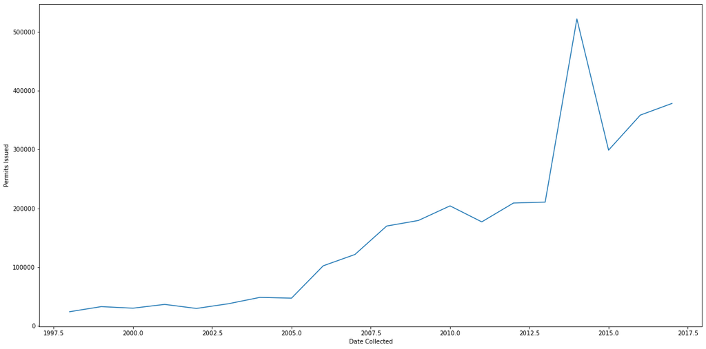

```python
# Grabbing the 'Date Collected' column and 'Permits Issued', grouping by column and plotting a line graph by year.

plt.figure(figsize=(20, 10))

plt.xlabel('Date Collected')
plt.ylabel('Permits Issued')

gun_df2.groupby(gun_df2['Date Collected'].dt.year)['Permits Issued'].max().plot()
plt.show()
```

> From the above graph we can see that there has been a consistent uptrend from 1998-2017. 2005-2012 seen a significant uptick in gun permits being issued while in 2014 we can see that there was a significant spike. The Assault Weapons ban of 2013 was a bill that was introduced to congress on January of 2013, a month after the Sandy Hook Massacre. The bill proposed a ban of automatic fed assault style weapons. The link below goes into extensive detail about what exactly would be included in the bill. Let's explore the spike in 2014 below.

> **Assault Weapons ban of 2013:**

> https://www.congress.gov/bill/113th-congress/senate-bill/150

## 2. What caused the spike of gun permits being issued in 2014, what states had the highest amount of gun permits being issued?

```python
# Grabbing all of the dates in 2014 and finding the states with the largest amount of permits issued.
# We can see that North Carolina, Kentucky, Illinois, and Indiana had the largest amount of permits.

year_max = gun_df2[gun_df2["Date Collected"].isin(pd.date_range("2014-01-01", "2014-12-01"))]
year_max.nlargest(20, 'Permits Issued')
year_maxresult = year_max.nlargest(20, 'Permits Issued')
year_maxresult
```

|  | Date Collected | State | Permits Issued |
| --- | --- | --- | --- |
| 2345 | 2014-03-01 | North Carolina | 522188.0 |
| 1833 | 2014-12-01 | Kentucky | 259142.0 |
| 2328 | 2014-03-01 | Kentucky | 257321.0 |
| 2273 | 2014-04-01 | Kentucky | 255799.0 |
| 2438 | 2014-01-01 | Kentucky | 240641.0 |
| 2108 | 2014-07-01 | Kentucky | 232847.0 |
| 2383 | 2014-02-01 | Kentucky | 227921.0 |
| 2218 | 2014-05-01 | Kentucky | 214214.0 |
| 2053 | 2014-08-01 | Kentucky | 213126.0 |
| 2400 | 2014-02-01 | North Carolina | 199748.0 |
| 2163 | 2014-06-01 | Kentucky | 199326.0 |
| 2324 | 2014-03-01 | Illinois | 102752.0 |
| 1829 | 2014-12-01 | Illinois | 101641.0 |
| 1885 | 2014-11-01 | Indiana | 96876.0 |
| 2434 | 2014-01-01 | Illinois | 89150.0 |
| 1994 | 2014-09-01 | Illinois | 88071.0 |
| 2159 | 2014-06-01 | Illinois | 87691.0 |
| 2379 | 2014-02-01 | Illinois | 78016.0 |
| 2269 | 2014-04-01 | Illinois | 72734.0 |
| 1939 | 2014-10-01 | Illinois | 70325.0 |

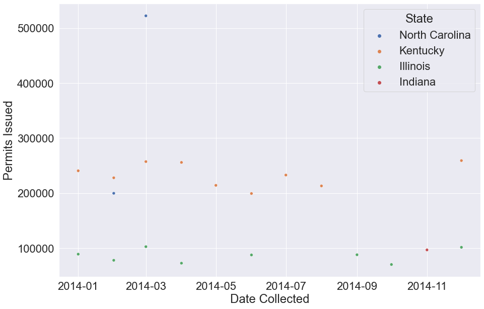

```python
# Grabbing 'Date Collected', 'Permits Issued' and using 'State' from year_maxresult (the states with the largest amount of
# gun permits issed in 2014) to plot a scatterplot. Using seaborn to make it pretty.

plt.figure(figsize=(15, 10))

sns.set(font_scale=2)
sns.set_style('darkgrid')
sns.scatterplot(data=year_maxresult, x="Date Collected", y="Permits Issued", hue="State")
plt.show()
```

> The news article, written in December of 2012, was talking about the Newton, Connecticut shooting and how people wanted to arm themselves more. The article went on to talk about gun laws on the federal, state, and local level and how they would be affected by the upcoming 2013 fire arm bill. Another article from the same news station talks about the sweeping 2013 gun bill in North Carolina. This was not The Assault Weapons Bill of 2013 that congress introduced to put a federal ban on automatic assautl weapons. The state law expanded on people being able to bring concealed carry guns into bars and as well as removing information about those who hold a conceal carry permit from public view. It would also roll back restrictions on sheriffs and how many handgun permits they are allowed to sign off on. The bill also strenghtened penalties for those who violate gun laws and would require that mental illness be included in the background checks.

> One could only reasonably assume that after a horrific tragedy like the Newton, Connecticut massacre that people would want to buy more guns to protect themselves. It could also be reasonably assumed that if a new gun law was being proposed in 2013 at the state and federal level, people were afraid that new gun restrictions might go into place and they were trying to get their hands on a firearm beforehand.

> **Article source, December 2012:**

> https://www.wral.com/q-a-gun-terms-and-laws/11901193/

> **Article source, July 2013:**

> https://www.wral.com/lawmakers-approve-sweeping-gun-measure/12695733/

### 3. From 2011-2015, how did the states with the highest gun permits issued compare to:

>

> The percentage of people with a bachelors degree or higher

> The percentage of people with a disability

> The percentage of people who went without health insurance

> The percentage of persons in poverty

> The percentage of people who are foreign born

> The percentage of people (5 years or age and older) who speak more than one language at home

```python
# Establishing that North Carolina and Kentucky had the largest amount of gun permits issued from 2011-2015.

five_yearmax = gun_df2[gun_df2["Date Collected"].isin(pd.date_range("2011-01-01", "2015-12-01"))]
five_yearmax.nlargest(10, 'Permits Issued')
```

|  | Date Collected | State | Permits Issued |
| --- | --- | --- | --- |
| 2345 | 2014-03-01 | North Carolina | 522188.0 |
| 1778 | 2015-01-01 | Kentucky | 298959.0 |
| 1393 | 2015-08-01 | Kentucky | 266788.0 |
| 1228 | 2015-11-01 | Kentucky | 264140.0 |
| 1833 | 2014-12-01 | Kentucky | 259142.0 |
| 1668 | 2015-03-01 | Kentucky | 258825.0 |
| 1173 | 2015-12-01 | Kentucky | 258154.0 |
| 2328 | 2014-03-01 | Kentucky | 257321.0 |
| 2273 | 2014-04-01 | Kentucky | 255799.0 |
| 1558 | 2015-05-01 | Kentucky | 255314.0 |

```python
# Isolating test_df for only 'North Carolina' in 'State'.

test_df = gun_df2[gun_df2['State'] == 'North Carolina']

# Passing in the specific dates (2011-2015) into test_df, creating new variable test_df2.

test_df2 = test_df[test_df["Date Collected"].isin(pd.date_range("2011-01-01", "2015-12-01"))]

# Creating a variable for our total of permits issued in North Carolina from 2011-2015.

permit_num = test_df2['Permits Issued'].sum()

# Creating the values I'm going to pass into the finalnc_df.

nc_df = [['North Carolina', permit_num]]

# Creating the finalnc_df.

finalnc_df = pd.DataFrame(nc_df, columns=['State', 'Total Permits Issued'])

finalnc_df
```

|  | State | Total Permits Issued |
| --- | --- | --- |
| 0 | North Carolina | 1921979.0 |

```python
# Isolating test_df for only 'Kentucky' in 'State'.

test_df3 = gun_df2[gun_df2['State'] == 'Kentucky']

# Passing in the specific dates (2011-2015) into test_df, creating new variable test_df4.

test_df4 = test_df3[test_df3["Date Collected"].isin(pd.date_range("2011-01-01", "2015-12-01"))]

# Creating a variable for our total of permits issued in Kentucky from 2011-2015.

permit_num2 = test_df4['Permits Issued'].sum()

# Creating the values I'm going to pass into the finalnc_df.

ken_df = [['Kentucky', permit_num2]]

# Creating the finalnc_df.

finalken_df = pd.DataFrame(ken_df, columns=['State', 'Total Permits Issued'])

finalken_df
```

|  | State | Total Permits Issued |
| --- | --- | --- |
| 0 | Kentucky | 10713721.0 |

```python
# Merging finalnc_df and finalken_df

state_df = pd.concat([finalnc_df, finalken_df])
state_df
```

|  | State | Total Permits Issued |
| --- | --- | --- |
| 0 | North Carolina | 1921979.0 |
| 0 | Kentucky | 10713721.0 |

```python
# Transposing the state_df (this will work better when we concat later)

transpose_statedf = state_df.T
transpose_statedf
```

|  | 0 | 0 |
| --- | --- | --- |
| State | North Carolina | Kentucky |
| Total Permits Issued | 1921979.0 | 10713721.0 |

```python
# Renaming the columns

transpose_statedf.columns = ["North Carolina", "Kentucky"]
transpose_statedf
```

|  | North Carolina | Kentucky |
| --- | --- | --- |
| State | North Carolina | Kentucky |
| Total Permits Issued | 1921979.0 | 10713721.0 |

```python
# dropping the first row as we will not be needing it.

transpose_statedf=transpose_statedf.drop(transpose_statedf.index[0])
transpose_statedf
```

|  | North Carolina | Kentucky |
| --- | --- | --- |
| Total Permits Issued | 1921979.0 | 10713721.0 |

```python
# Resetting the index

transpose_statedf = transpose_statedf.reset_index()
transpose_statedf
```

|  | index | North Carolina | Kentucky |
| --- | --- | --- | --- |
| 0 | Total Permits Issued | 1921979.0 | 10713721.0 |

```python
# Renaming 'index' to 'Fact'

transpose_statedf.rename(columns = {'index':'Fact'}, inplace = True)
transpose_statedf
```

|  | Fact | North Carolina | Kentucky |
| --- | --- | --- | --- |
| 0 | Total Permits Issued | 1921979.0 | 10713721.0 |

```python
# Creating an index list of rows I need.

census_index = [0, 35, 36, 37, 49, 33, 21]

# Passing the census_index into iloc to show the dataframe.

census_select = census_df2.iloc[census_index]

# Selecting the columns I need.

ncken_select = census_select[['Fact', 'North Carolina', 'Kentucky']]

ncken_select
```

|  | Fact | North Carolina | Kentucky |
| --- | --- | --- | --- |
| 0 | Population estimates, July 1, 2016, (V2016) | 10146788 | 4,436,974 |
| 35 | Bachelor's degree or higher, percent of person... | 0.284 | 22.30% |
| 36 | With a disability, under age 65 years, percent... | 0.096 | 12.90% |
| 37 | Persons without health insurance, under age 6... | 0.122 | 6.00% |
| 49 | Persons in poverty, percent | 0.154 | 18.50% |
| 33 | Language other than English spoken at home, pe... | 0.112 | 5.10% |
| 21 | Foreign born persons, percent, 2011-2015 | 0.077 | 3.40% |

```python
# Creating the final_merged dataframe and resetting index.

final_merge = pd.concat([transpose_statedf, ncken_select]).reset_index()

final_merge
```

|  | index | Fact | North Carolina | Kentucky |
| --- | --- | --- | --- | --- |
| 0 | 0 | Total Permits Issued | 1921979.0 | 10713721.0 |
| 1 | 0 | Population estimates, July 1, 2016, (V2016) | 10146788 | 4,436,974 |
| 2 | 35 | Bachelor's degree or higher, percent of person... | 0.284 | 22.30% |
| 3 | 36 | With a disability, under age 65 years, percent... | 0.096 | 12.90% |
| 4 | 37 | Persons without health insurance, under age 6... | 0.122 | 6.00% |
| 5 | 49 | Persons in poverty, percent | 0.154 | 18.50% |
| 6 | 33 | Language other than English spoken at home, pe... | 0.112 | 5.10% |
| 7 | 21 | Foreign born persons, percent, 2011-2015 | 0.077 | 3.40% |

```python
# Cleaning up the column name.

final_merge.rename(columns={'Fact': '2011-2015 facts'}, inplace=True)

final_merge
```

|  | index | 2011-2015 facts | North Carolina | Kentucky |
| --- | --- | --- | --- | --- |
| 0 | 0 | Total Permits Issued | 1921979.0 | 10713721.0 |
| 1 | 0 | Population estimates, July 1, 2016, (V2016) | 10146788 | 4,436,974 |
| 2 | 35 | Bachelor's degree or higher, percent of person... | 0.284 | 22.30% |
| 3 | 36 | With a disability, under age 65 years, percent... | 0.096 | 12.90% |
| 4 | 37 | Persons without health insurance, under age 6... | 0.122 | 6.00% |
| 5 | 49 | Persons in poverty, percent | 0.154 | 18.50% |
| 6 | 33 | Language other than English spoken at home, pe... | 0.112 | 5.10% |
| 7 | 21 | Foreign born persons, percent, 2011-2015 | 0.077 | 3.40% |